# R Notebook

```r
library(C50)
library(caret)
library(randomForest)
```

Reading the data and assigning it to a variable

```r
tabA <- read.csv("TABULAR_A.csv")
tabB <- read.csv("TABULAR_B.csv")
```

Displaying first 3 row from tabA

```r
head(tabA,n = 3)
```

|  | owner_id | car_price | maint_cost | num_doors | person_capacity | trunk_size | safety_rating | car_rank |
| --- | --- | --- | --- | --- | --- | --- | --- | --- |
| 1 | 1 | 4 | 4 | 2 | 2 | 1 | 1 | unacc |
| 2 | 2 | 4 | 4 | 2 | 2 | 1 | 2 | unacc |
| 3 | 3 | 4 | 4 | 2 | 2 | 1 | 3 | unacc |

```r
tail(tabB,n = 3)
```

|  | owner_id | income | age |
| --- | --- | --- | --- |
| 666 | 1717 | 71000 | 64 |
| 667 | 1722 | 170000 | 36 |
| 668 | 1722 | 170000 | 36 |

loading sqldf library

```r
library(sqldf)
```

Query and find each count in car_rank category

```r
sqldf("select car_rank, count(*) as tot from tabA group by car_rank order by tot desc")
```

| car_rank | tot |
| --- | --- |
| unacc | 1210 |
| acc | 384 |
| good | 69 |
| vgood | 65 |

Leftouter join with tabB and find the category

```r
sqldf("select a.car_rank, count(*) as tot from tabA as a left outer join tabB as b  on a.owner_id = b.owner_id group by a.car_rank order by tot desc")
```

| car_rank | tot |
| --- | --- |
| unacc | 1273 |
| acc | 400 |
| vgood | 79 |
| good | 77 |

find the duplicates of owner_id in tabB

```r
sqldf("SELECT owner_id, COUNT(*) count FROM tabB GROUP BY owner_id HAVING count > 1")
```

| owner_id | count |
| --- | --- |
| 1392 | 2 |
| 1393 | 2 |
| 1396 | 2 |
| 1401 | 2 |
| 1405 | 2 |
| 1406 | 2 |
| 1409 | 2 |
| 1410 | 2 |
| 1415 | 2 |
| 1416 | 2 |

[output cut: 91 more lines]

Segmenting tht tabA with 3 clusters

```r
set.seed(21)
tabACluster <- kmeans(tabA[, 2:7], 3,nstart = 20)
tabACluster
```

```
K-means clustering with 3 clusters of sizes 576, 576, 576

Cluster means:
  car_price maint_cost num_doors person_capacity trunk_size safety_rating
1       3.5        2.5       3.5             4.5          2             2
2       2.5        2.5       3.5             2.0          2             2
3       1.5        2.5       3.5             4.5          2             2

Clustering vector:
   [1] 2 2 2 2 2 2 2 2 2 1 1 1 1 1 1 1 1 1 1 1 1 1 1 1 1 1 1 2 2 2 2 2 2 2 2 2 1 1 1 1 1 1 1 1 1 1 1 1 1 1 1 1 1 1
  [55] 2 2 2 2 2 2 2 2 2 1 1 1 1 1 1 1 1 1 1 1 1 1 1 1 1 1 1 2 2 2 2 2 2 2 2 2 1 1 1 1 1 1 1 1 1 1 1 1 1 1 1 1 1 1
 [109] 2 2 2 2 2 2 2 2 2 1 1 1 1 1 1 1 1 1 1 1 1 1 1 1 1 1 1 2 2 2 2 2 2 2 2 2 1 1 1 1 1 1 1 1 1 1 1 1 1 1 1 1 1 1
 [163] 2 2 2 2 2 2 2 2 2 1 1 1 1 1 1 1 1 1 1 1 1 1 1 1 1 1 1 2 2 2 2 2 2 2 2 2 1 1 1 1 1 1 1 1 1 1 1 1 1 1 1 1 1 1
 [217] 2 2 2 2 2 2 2 2 2 1 1 1 1 1 1 1 1 1 1 1 1 1 1 1 1 1 1 2 2 2 2 2 2 2 2 2 1 1 1 1 1 1 1 1 1 1 1 1 1 1 1 1 1 1
 [271] 2 2 2 2 2 2 2 2 2 1 1 1 1 1 1 1 1 1 1 1 1 1 1 1 1 1 1 2 2 2 2 2 2 2 2 2 1 1 1 1 1 1 1 1 1 1 1 1 1 1 1 1 1 1
 [325] 2 2 2 2 2 2 2 2 2 1 1 1 1 1 1 1 1 1 1 1 1 1 1 1 1 1 1 2 2 2 2 2 2 2 2 2 1 1 1 1 1 1 1 1 1 1 1 1 1 1 1 1 1 1
 [379] 2 2 2 2 2 2 2 2 2 1 1 1 1 1 1 1 1 1 1 1 1 1 1 1 1 1 1 2 2 2 2 2 2 2 2 2 1 1 1 1 1 1 1 1 1 1 1 1 1 1 1 1 1 1
 [433] 2 2 2 2 2 2 2 2 2 1 1 1 1 1 1 1 1 1 1 1 1 1 1 1 1 1 1 2 2 2 2 2 2 2 2 2 1 1 1 1 1 1 1 1 1 1 1 1 1 1 1 1 1 1
 [487] 2 2 2 2 2 2 2 2 2 1 1 1 1 1 1 1 1 1 1 1 1 1 1 1 1 1 1 2 2 2 2 2 2 2 2 2 1 1 1 1 1 1 1 1 1 1 1 1 1 1 1 1 1 1
 [541] 2 2 2 2 2 2 2 2 2 1 1 1 1 1 1 1 1 1 1 1 1 1 1 1 1 1 1 2 2 2 2 2 2 2 2 2 1 1 1 1 1 1 1 1 1 1 1 1 1 1 1 1 1 1
 [595] 2 2 2 2 2 2 2 2 2 1 1 1 1 1 1 1 1 1 1 1 1 1 1 1 1 1 1 2 2 2 2 2 2 2 2 2 1 1 1 1 1 1 1 1 1 1 1 1 1 1 1 1 1 1
 [649] 2 2 2 2 2 2 2 2 2 1 1 1 1 1 1 1 1 1 1 1 1 1 1 1 1 1 1 2 2 2 2 2 2 2 2 2 1 1 1 1 1 1 1 1 1 1 1 1 1 1 1 1 1 1
 [703] 2 2 2 2 2 2 2 2 2 1 1 1 1 1 1 1 1 1 1 1 1 1 1 1 1 1 1 2 2 2 2 2 2 2 2 2 1 1 1 1 1 1 1 1 1 1 1 1 1 1 1 1 1 1
 [757] 2 2 2 2 2 2 2 2 2 1 1 1 1 1 1 1 1 1 1 1 1 1 1 1 1 1 1 2 2 2 2 2 2 2 2 2 1 1 1 1 1 1 1 1 1 1 1 1 1 1 1 1 1 1
 [811] 2 2 2 2 2 2 2 2 2 1 1 1 1 1 1 1 1 1 1 1 1 1 1 1 1 1 1 2 2 2 2 2 2 2 2 2 1 1 1 1 1 1 1 1 1 1 1 1 1 1 1 1 1 1
 [865] 2 2 2 2 2 2 2 2 2 3 3 3 3 3 3 3 3 3 3 3 3 3 3 3 3 3 3 2 2 2 2 2 2 2 2 2 3 3 3 3 3 3 3 3 3 3 3 3 3 3 3 3 3 3
 [919] 2 2 2 2 2 2 2 2 2 3 3 3 3 3 3 3 3 3 3 3 3 3 3 3 3 3 3 2 2 2 2 2 2 2 2 2 3 3 3 3 3 3 3 3 3 3 3 3 3 3 3 3 3 3
 [973] 2 2 2 2 2 2 2 2 2 3 3 3 3 3 3 3 3 3 3 3 3 3 3 3 3 3 3 2
 [ reached getOption("max.print") -- omitted 728 entries ]

Within cluster sum of squares by cluster:
[1] 2496 2928 2496
 (between_SS / total_SS =  31.0 %)

Available components:

[1] "cluster"      "centers"      "totss"        "withinss"     "tot.withinss" "betweenss"    "size"
[8] "iter"         "ifault"
```

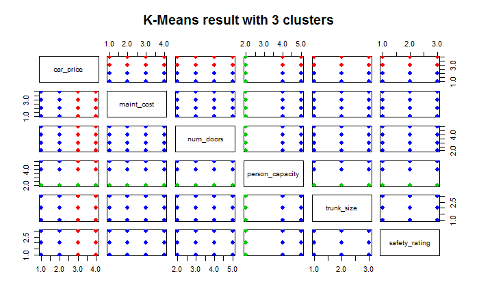

```r
plot(tabA[, 2:7], col =(tabACluster$cluster +1) , main="K-Means result with 3 clusters", pch=20, cex=2)
```

Comparing the cluster obtained with car_rank distribution

```r
table(tabACluster$cluster, tabA$car_rank)
```

```
    acc good unacc vgood
  1 180    0   396     0
  2   0    0   576     0
  3 204   69   238    65
```

Converting the cluster label to factor variable

```r
clust <- as.factor(tabACluster$cluster)
```

Merging the cluster label with the tabA

```r
tabA <- cbind(tabA,clust)
str(tabA)
```

```
'data.frame':   1728 obs. of  9 variables:
 $ owner_id       : int  1 2 3 4 5 6 7 8 9 10 ...
 $ car_price      : int  4 4 4 4 4 4 4 4 4 4 ...
 $ maint_cost     : int  4 4 4 4 4 4 4 4 4 4 ...
 $ num_doors      : int  2 2 2 2 2 2 2 2 2 2 ...
 $ person_capacity: int  2 2 2 2 2 2 2 2 2 4 ...
 $ trunk_size     : int  1 1 1 2 2 2 3 3 3 1 ...
 $ safety_rating  : int  1 2 3 1 2 3 1 2 3 1 ...
 $ car_rank       : Factor w/ 4 levels "acc","good","unacc",..: 3 3 3 3 3 3 3 3 3 3 ...
 $ clust          : Factor w/ 3 levels "1","2","3": 2 2 2 2 2 2 2 2 2 1 ...
```

Segregating the data based on their cluster obtained

```r
tabA_1 = tabA[with(tabA, clust == "1" ),]
tabA_2 = tabA[with(tabA, clust == "2" ),]
tabA_3 = tabA[with(tabA, clust == "3" ),]
```

comparing the distribution of data across cluster and car_rank

```r
table(tabA_1$clust, tabA_1$car_rank)
```

```
    acc good unacc vgood
  1 180    0   396     0
  2   0    0     0     0
  3   0    0     0     0
```

```r
table(tabA_2$clust, tabA_2$car_rank)
```

```
    acc good unacc vgood
  1   0    0     0     0
  2   0    0   576     0
  3   0    0     0     0
```

```r
table(tabA_3$clust, tabA_3$car_rank)
```

```
    acc good unacc vgood
  1   0    0     0     0
  2   0    0     0     0
  3 204   69   238    65
```

Cluster 1: The car_rank contains two class Cluster 2: The car_rank contains only one class Cluster 3: The car_rank contains all 4 class ******************************************************************************

| Modeling |
| --- |

Spliting data to train and test Function to re-use the code on each clusters

```r
splitData <- function(x){
# Divide the data into test and train
set.seed(123)
train_RowIDs = sample(1:nrow(x), nrow(x)*0.7)
train_Data = x[train_RowIDs,]
test_Data = x[-train_RowIDs,]
dataList<- list("train"= train_Data, "test"= test_Data)
return(dataList)
rm(train_RowIDs)
}
```

```r
tabA_1_split <- splitData(tabA_2)
tabA_3_split <- splitData(tabA_3)
```

```r
decisionTree_C5(tabA_1_split)
```

[output not shown]

Running the decision tree on cluster 3 data

```
Call:
rpart(formula = car_rank ~ car_price + maint_cost + num_doors +
    person_capacity + trunk_size + safety_rating, data = dataf$train,
    method = "class")
  n= 403

          CP nsplit rel error    xerror       xstd
1 0.46320346      0 1.0000000 1.0000000 0.04298389
2 0.04978355      1 0.5367965 0.5367965 0.04010961
3 0.04761905      4 0.3809524 0.5194805 0.03973922
4 0.02813853      5 0.3333333 0.4025974 0.03661490
5 0.02597403      7 0.2770563 0.4025974 0.03661490
6 0.02164502      9 0.2251082 0.3203463 0.03364723
7 0.01731602     10 0.2034632 0.3203463 0.03364723
8 0.01000000     12 0.1688312 0.2987013 0.03273658

Variable importance
safety_rating    maint_cost    trunk_size     car_price     num_doors
           57            17            16             5             4

Node number 1: 403 observations,    complexity param=0.4632035
  predicted class=unacc  expected loss=0.573201  P(node) =1
    class counts:   140    51   172    40
   probabilities: 0.347 0.127 0.427 0.099
  left son=2 (264 obs) right son=3 (139 obs)
  Primary splits:
      safety_rating < 1.5 to the right, improve=100.811300, (0 missing)
      maint_cost    < 2.5 to the right, improve= 16.633060, (0 missing)
      trunk_size    < 1.5 to the left,  improve=  5.703484, (0 missing)
      car_price     < 1.5 to the right, improve=  2.593197, (0 missing)
      num_doors     < 3.5 to the left,  improve=  1.536197, (0 missing)

Node number 2: 264 observations,    complexity param=0.04978355
  predicted class=acc    expected loss=0.469697  P(node) =0.6550868
    class counts:   140    51    33    40
   probabilities: 0.530 0.193 0.125 0.152
  left son=4 (133 obs) right son=5 (131 obs)
  Primary splits:
      maint_cost    < 2.5 to the right, improve=25.304840, (0 missing)
      safety_rating < 2.5 to the left,  improve= 8.970687, (0 missing)
```

[output cut: 253 more lines]

```

                  Kappa : 0.7866
 Mcnemar's Test P-Value : NA

Statistics by Class:

                     Class: acc Class: good Class: unacc Class: vgood
Sensitivity              0.7945     0.63158       0.9531      1.00000
Specificity              0.9400     0.96104       0.9541      0.94872
Pos Pred Value           0.9062     0.66667       0.9242      0.68000
Neg Pred Value           0.8624     0.95484       0.9720      1.00000
Prevalence               0.4220     0.10983       0.3699      0.09827
Detection Rate           0.3353     0.06936       0.3526      0.09827
Detection Prevalence     0.3699     0.10405       0.3815      0.14451
Balanced Accuracy        0.8673     0.79631       0.9536      0.97436
```

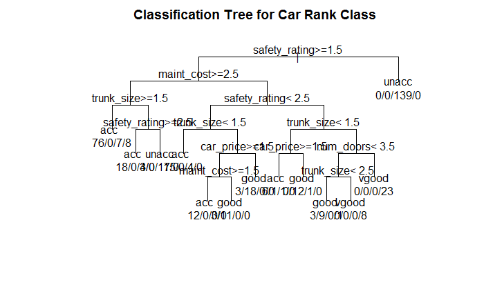

```r
decisionTree_rpart(tabA_3_split)
```

Modelbuilding using Decision Tree using C5.0

Wrinting function to reuse

```r
decisionTree_C5 <- function(dataf){
dtC50 = C5.0(car_rank~car_price + maint_cost   + trunk_size + safety_rating, data = dataf$train, rules=TRUE)

#summarize the rules
summary(dtC50)


#predicting the train data
ctrain = table(dataf$train$car_rank, predict(dtC50, newdata=dataf$train, type="class"))
print("Train Error Metrics")
ctrain_confusion <- confusionMatrix(ctrain)
print(ctrain_confusion)

#predicting the test data
ctest=table(dataf$test$car_rank, predict(dtC50, newdata=dataf$test, type="class"))
print("Test Error Metrics")
ctest_confusion <- confusionMatrix(ctest)
print(ctest_confusion)

}
```

```r
decisionTree_C5(tabA_3_split)
```

```
[1] "Train Error Metrics"
Confusion Matrix and Statistics


        acc good unacc vgood
  acc   125    6     4     5
  good    1   41     0     9
  unacc  15    1   156     0
  vgood   0    0     0    40

Overall Statistics

               Accuracy : 0.8983
                 95% CI : (0.8645, 0.926)
    No Information Rate : 0.397
    P-Value [Acc > NIR] : < 2.2e-16

                  Kappa : 0.8505
 Mcnemar's Test P-Value : NA

Statistics by Class:

                     Class: acc Class: good Class: unacc Class: vgood
Sensitivity              0.8865      0.8542       0.9750      0.74074
Specificity              0.9427      0.9718       0.9342      1.00000
Pos Pred Value           0.8929      0.8039       0.9070      1.00000
Neg Pred Value           0.9392      0.9801       0.9827      0.96143
Prevalence               0.3499      0.1191       0.3970      0.13400
Detection Rate           0.3102      0.1017       0.3871      0.09926
Detection Prevalence     0.3474      0.1266       0.4268      0.09926
Balanced Accuracy        0.9146      0.9130       0.9546      0.87037
[1] "Test Error Metrics"
Confusion Matrix and Statistics


        acc good unacc vgood
  acc    57    3     3     1
  good    6   12     0     0
  unacc   4    1    61     0
  vgood   0    0     0    25

Overall Statistics

               Accuracy : 0.896
                 95% CI : (0.8406, 0.9372)
    No Information Rate : 0.3873
    P-Value [Acc > NIR] : < 2.2e-16

                  Kappa : 0.8479
 Mcnemar's Test P-Value : NA

Statistics by Class:

                     Class: acc Class: good Class: unacc Class: vgood
Sensitivity              0.8507     0.75000       0.9531       0.9615
Specificity              0.9340     0.96178       0.9541       1.0000
Pos Pred Value           0.8906     0.66667       0.9242       1.0000
Neg Pred Value           0.9083     0.97419       0.9720       0.9932
Prevalence               0.3873     0.09249       0.3699       0.1503
Detection Rate           0.3295     0.06936       0.3526       0.1445
Detection Prevalence     0.3699     0.10405       0.3815       0.1445
Balanced Accuracy        0.8924     0.85589       0.9536       0.9808
```